# Visualisation I

Bar plots and distributions · 7AAVBCS5

Dr Mark J. Hill · mark.j.hill@kcl.ac.uk

11 November 2026

## Lecture plan

**How do chart choices change what we see in London venue records, borough summaries and bike hires?**

- Why visualise? Exploration, explanation and misleading graphics
- Bar plots: categories, ordering, units and denominators
- Crosstabs: counts, composition and shared baselines
- Distributions: centre, spread, skew and unusual values
- Saving figures, live coding and applied exercises

## Key learning outcomes

By the end of the week, you should be able to:

- choose between bar plots and histograms
- create readable bar plots from frequency tables and crosstabs
- use grouped, stacked and proportional bar plots appropriately
- describe distributions using mean, median, quartiles and range
- identify skew, outliers and suspicious values
- save figures in appropriate formats for reporting

## The tables from Monday

| Question | Table | Chart today |
| --- | --- | --- |
| Entries of each type? | `value_counts()` | bar plot |
| Borough compositions? | `pd.crosstab()` | grouped, stacked or proportional bars |
| A numerical summary for each group? | `groupby().agg()` | bars comparing mean and median hire duration |
| Where do rates or durations cluster? | `describe()` | histogram |

A chart inherits the table’s **counting unit, classification, missingness and denominator**.

## What we are plotting

| File | Unit | Coverage used today |
| --- | --- | --- |
| Venue extract | register entry | 4,434 entries, 26 types; no missing borough/type labels |
| Borough context | administrative area | 32 boroughs + City; 33 complete count, population, area and rate values |
| TfL hire extract | recorded hire | 443,539 hires, 16–31 July 2025; 12 starting borough areas; complete duration and grouping fields |

The **2023 release** combines layers captured largely in **2022**; population is **2015**. These rates compare mismatched dates, rather than measure current cultural access.

# Why visualise?

1. **Choose the purpose:** explore data or explain a finding.
2. **Read examples:** see what a chart adds to a table or sentence.
3. **Check the design:** axes, positions, arithmetic and the story they suggest.
4. **Match the chart to the question:** categories, summaries or a distribution.

## Explore and explain

**Data → researcher → audience**

| Explore: understand the data | Explain: communicate a finding |
| --- | --- |
| Inspect distributions, gaps and unusual cases | Select evidence relevant to a question |
| Check assumptions and possible errors | Give readable labels, units and context |
| Develop hypotheses; return to the records | Make a claim the evidence supports |

A rough histogram reveals the City’s unusual rate. A report figure must also explain its residential denominator.

## Tables are sometimes better

| Borough | Register entries | Entries per 10,000 residents |
| --- | --- | --- |
| Westminster | 653 | 28.32 |
| City of London | 111 | 137.04 |

Tables preserve exact values, combine labels and numbers, support lookup and can be sorted in different ways. A sentence may suffice for one comparison.

Use a chart when **position, shape or pattern** makes something easier to understand.

## How many sevens?

1718904628438518627542393187328934935881437223982143987452196385427954523651582632584123813241822145631473325711934236850125489631541266828135852584632971247926361513321826841931841189

## The same numbers, with sevens highlighted

1718904628438518627542393187328934935881437223982143987452196385427954523651582632584123813241822145631473325711934236850125489631541266828135852584632971247926361513321826841931841189

## The distribution reveals the gap

| Digit | 0 | 1 | 2 | 3 | 4 | 5 | 6 | 7 | 8 | 9 |
| --- | --- | --- | --- | --- | --- | --- | --- | --- | --- | --- |
| Count | 2 | 27 | 27 | 26 | 20 | 19 | 14 | 10 | 25 | 14 |

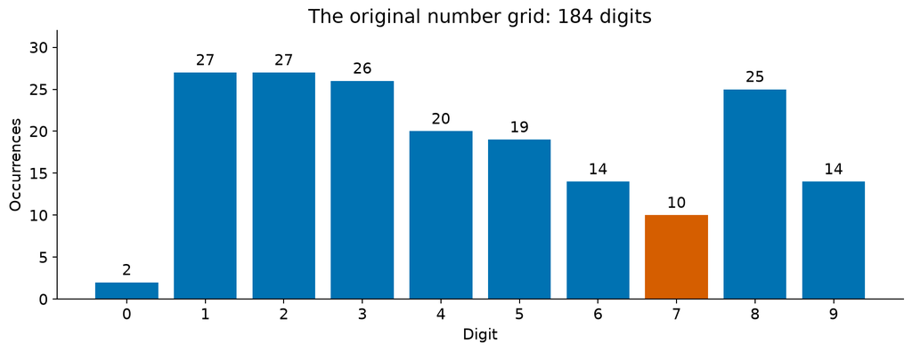

Seven occurs **10 times among 184 digits**. Its low frequency is easier to see against the other counts than in the grid.

## Why visualisation matters

- **Discovery:** a distribution exposes a gap or tail a mean hides.
- **Quality control:** an isolated value tells us where to investigate.
- **Communication:** a comparison becomes visible before every number is read.
- **Argument:** design directs attention towards an interpretation.

> “The simple graph has brought more information to the data analyst’s mind than any other device.”

John W. Tukey, *The Future of Data Analysis* (1962)

## What a chart should add

Visualisation has a long history across statistics, design, cartography and the humanities.

**A useful figure makes a pattern or comparison easier to see than the raw table or a short sentence does.**

For London, 33 exact rates belong in a table for lookup. Their concentration near the low end, and one long right tail, are easier to grasp in a histogram.

## Playfair: trade as a visual argument

[figure not shown]

William Playfair, *Commercial and Political Atlas* (1786).

- Years: 1700–1780
- Trade value in pounds; grid divisions £10,000
- Shading: balance “against” or “in favour of England”

The chart presents a political-economic interpretation, not just two lines.

## Snow: a persuasive map, a qualified story

[figure not shown]

**Each short black bar marks one cholera death at a recorded address.** Stacks of bars show multiple deaths; the pumps are labelled separately.

**Soho, 1854:** deaths cluster around the Broad Street pump, on today’s Broadwick Street.

Snow combined mapped deaths with inquiries about water use. Authorities removed the handle on **8 September**.

The outbreak was already declining. The later published map supports an argument; it does not prove that removing the handle ended the outbreak.

## Minard: several variables in one image

[figure not shown]

Width: **troop numbers**. Position: **location**. Colour: **outward/return journey**. Dates and temperature accompany the retreat.

Several variables tell one story, but the reader must learn the encodings. The temperature scale is **Réaumur**, not Celsius.

## Read the broadcast chart

[figure not shown]

The vertical axis starts at **94 million**, not zero. How large does the increase look before you read that scale?

## A zero baseline changes the impression

[figure not shown]

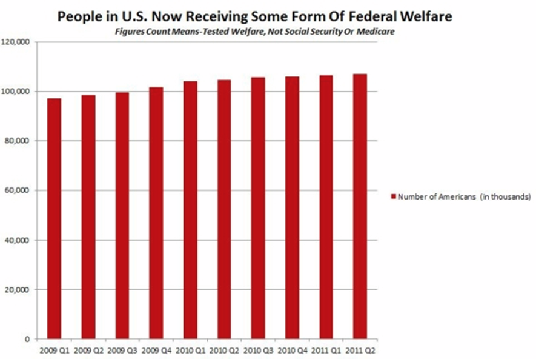

**Same displayed series, different visual impression.** Bars encode magnitude by length from a baseline. Removing the lower 94 million exaggerates relative change. Use zero for count bars.

## Axis direction changes a story

[figure not shown]

The Florida graphic places **zero at the top**. Downward movement represents a higher count.

Axis direction, scale and event annotations guide a narrative before the reader checks values.

A policy-date annotation does not establish causation. Visualisation II develops that explanation problem.

## Position should agree with the value

[figure not shown]

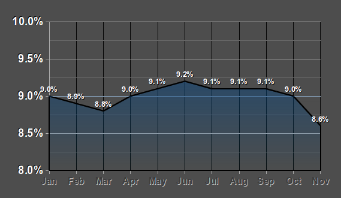

On an upward-increasing axis, the final **8.6%** point should be below earlier **8.8%** and **8.9%** points. Check labels against positions, not just apparent line direction.

## Check arithmetic as well as the picture

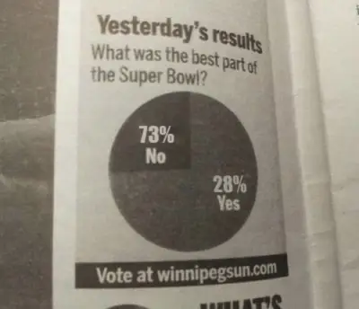

The Sun poll labels **73% No** and **28% Yes**: a total of **101%**.

Rounding can sometimes produce 101%, but the sector sizes also fail to match the labels.

Check totals, denominators and geometry. A humorous error is still a useful audit prompt.

## Choosing the right chart

| Data and question | London example | Useful chart |
| --- | --- | --- |
| Nominal category: counts | venue type | bars, frequency order |
| Ordinal category: counts | Low → Medium → High | bars, defined order |
| Numeric variable: distribution | entries per 10k residents | histogram |
| Two categories: counts or mix | borough × type | grouped/stacked/proportional bars |
| Comparable values over time | annual counts | line chart |
| Number by group / two numbers | rate by band / rate versus population | box plot / scatter (later) |

A numeric count can have a **distribution** too. Choose by the question as well as the dtype.

# Bar plots

1. **Reuse a table:** frequencies, crosstabs or grouped summaries.
2. **Draw readable bars:** labels, order, units and a zero baseline.
3. **Choose the comparison:** counts, rates, totals or composition.
4. **Read the result:** venue records, boroughs and bike hires count different things.

## Anatomy of a bar plot

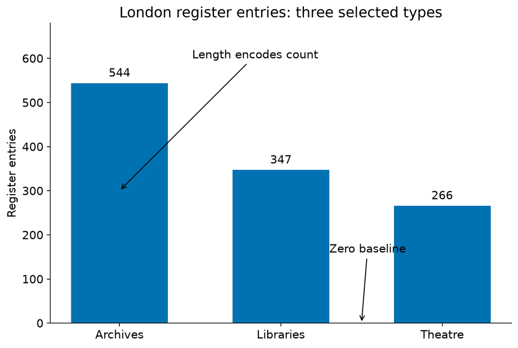

- One separated bar per category
- Length represents a count, proportion or other stated summary
- Zero baseline supports length comparisons
- Category labels identify groups; value axis names measure and units

Our first chart counts **register entries**, not distinct venues.

## One plotting pattern

```python
import pandas as pd
import matplotlib.pyplot as plt
venues = pd.read_csv(data_path("london_cultural_venues_2023.csv"))
borough_context = pd.read_csv(data_path(
    "london_cultural_infrastructure_2023_borough_context.csv"))
fig, ax = plt.subplots(figsize=(9, 4))
```

**`fig`** is the whole figure; **`ax`** is the plotting area. Draw on `ax`, label it, then save `fig`.

The notebooks supply `data_path()` to find local files or the Colab data checkout.

## First attempt: 26 long labels

```python
counts = venues["venue_type"].value_counts()
fig, ax = plt.subplots(figsize=(11, 4))
ax.bar(counts.index, counts.values)
ax.set_ylabel("Register entries")
```

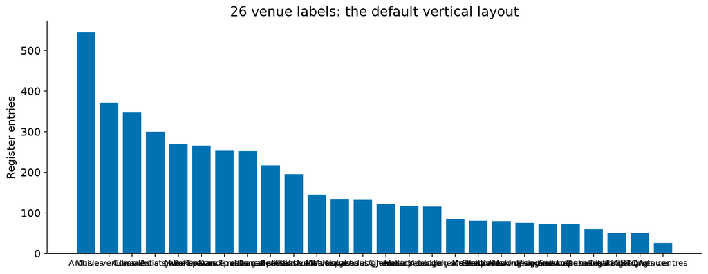

The counts are correct. The category labels are unreadable.

## Horizontal bars fit the labels

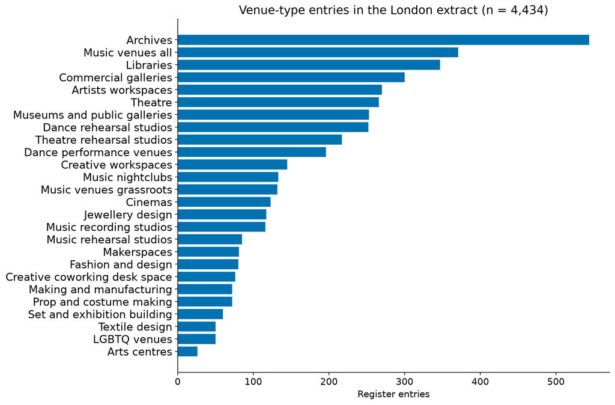

```python
fig, ax = plt.subplots(
    figsize=(11, 7))
ax.barh(counts.index,
        counts.values)
ax.invert_yaxis()
ax.set_xlabel(
    "Register entries")
```

**Archives: 544 entries.** The largest register category does not establish the most common kind of distinct cultural place.

## Reuse Monday’s ordered bands

Assign labels with the conditions we already used, then record their order.

```python
rate = borough_context["venues_per_10k_residents"]
borough_context["rate_band"] = ""
borough_context.loc[rate < 5, "rate_band"] = "Low"
borough_context.loc[(rate >= 5) & (rate < 15), "rate_band"] = "Medium"
borough_context.loc[rate >= 15, "rate_band"] = "High"
borough_context["rate_band"] = borough_context["rate_band"].astype("category")
borough_context["rate_band"] = borough_context["rate_band"].cat.set_categories(
    ["Low", "Medium", "High"], ordered=True)
```

These are our teaching thresholds. A band records a classification decision, not an official standard of provision.

## Ordering is an analytical choice

```python
bands = borough_context["rate_band"].value_counts(sort=False)
fig, ax = plt.subplots(figsize=(8, 3))
ax.bar(bands.index, bands.values)
ax.set_ylabel("Borough areas")
```

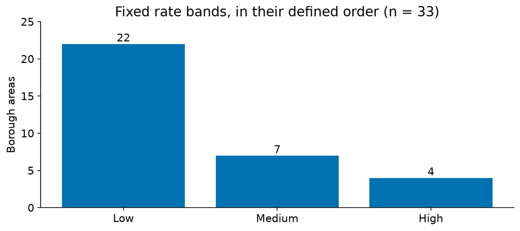

Nominal types can follow frequency. Ordinal bands retain their **defined order**.

## Titles, labels, colour and limits

```python
ax.set_title("London cultural infrastructure: venue-type entries")
ax.set_xlabel("Register entries")  # horizontal chart
ax.set_xlim(left=0)
ax.tick_params(axis="y", labelsize=11)
fig.tight_layout()
```

- Name the place, measure and relevant date or release.
- Preserve meaningful labels; explain abbreviations.
- Use one colour when colour encodes no extra information.
- Check long labels in the saved file at the intended size.

## Borough counts: Westminster leads

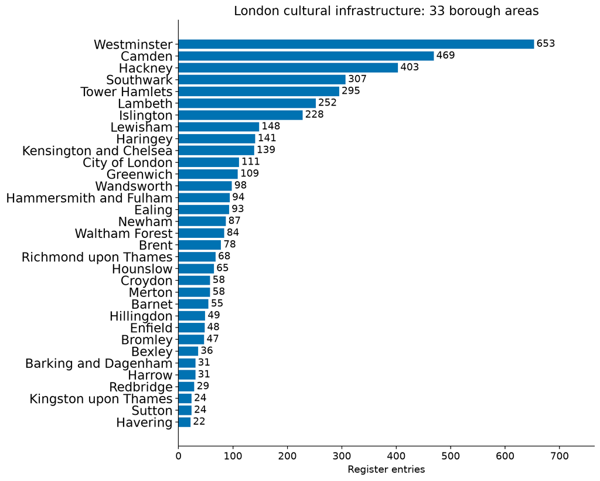

**653 Westminster entries**, compared with **111 City entries**.

Counts locate more entries, without adjusting for residents or area.

```python
ordered = borough_context
ordered = ordered.sort_values(
    "venues", ascending=False)
fig, ax = plt.subplots()
ax.barh(ordered["borough_name"],
        ordered["venues"])
ax.invert_yaxis()
```

## Per resident: the City leads

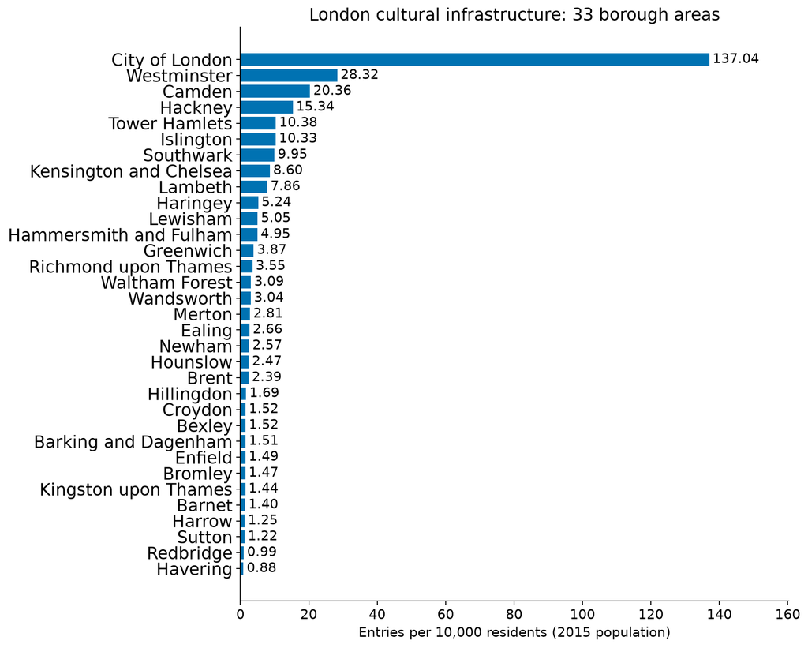

City: **111 ÷ 8,100 × 10,000 = 137.04**.

Westminster: **28.32 entries per 10,000 residents**.

The City serves workers and visitors too. This ratio does not measure individual access.

Population: **2015**. Register: **2023 release**, largely 2022 capture.

## Per area: concentration on the ground

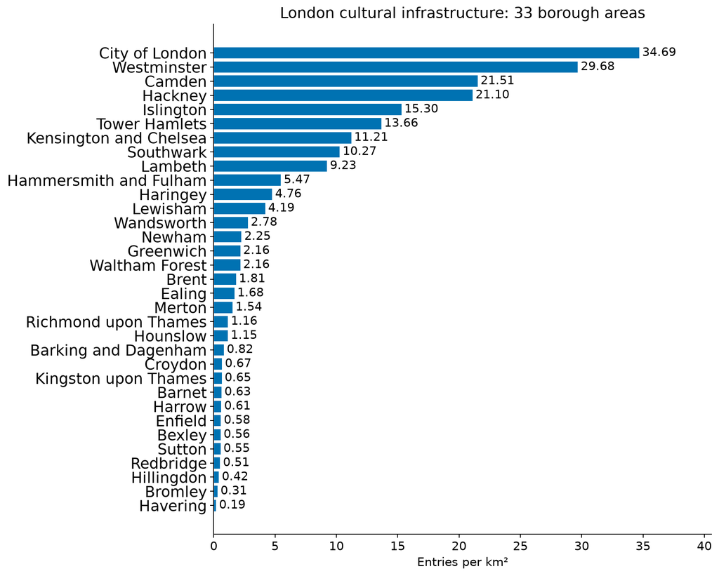

City: **111 ÷ 3.2 km² = 34.69 entries/km²**.

Westminster: **653 ÷ 22.0 km² = 29.68 entries/km²**.

Area describes spatial concentration. It does not tell us who can afford, reach or use the places.

Area field: supplied borough profile extract.

## Three measures, three questions

| Measure | Westminster | City | Question |
| --- | --- | --- | --- |
| Register entries | 653 | 111 | How many entries here? |
| Entries per 10,000 residents | 28.32 | 137.04 | How many relative to residents? |
| Entries per km² | 29.68 | 34.69 | How concentrated on the ground? |

**Chart choice includes choosing the quantity to plot.** A polished comparison of the wrong measure still answers the wrong question.

## Crosstabs: keep the whole denominator

```python
boroughs = ["Camden", "Hackney", "Westminster", "Havering"]
types = ["Libraries", "Music venues all", "Music nightclubs"]
ct = pd.crosstab(venues["borough_name"], venues["venue_type"])
mix = ct.loc[boroughs, types].copy()
mix["Other register types"] = ct.loc[boroughs].sum(axis=1) - mix.sum(axis=1)
```

| Borough | Libraries | Music all | Nightclubs | Other | Total |
| --- | --- | --- | --- | --- | --- |
| Camden | 12 | 36 | 9 | 412 | 469 |
| Hackney | 9 | 71 | 31 | 292 | 403 |
| Westminster | 11 | 52 | 25 | 565 | 653 |
| Havering | 10 | 0 | 0 | 12 | 22 |

“Other” combines remaining **register labels**. Places can still enter several registers.

## Stacked bars: totals and composition

```python
palette = ["#0072B2", "#E69F00", "#009E73", "#999999"]
fig, ax = plt.subplots(figsize=(10, 4))
mix.plot.bar(stacked=True, ax=ax, color=palette, rot=0)
ax.set_ylabel("Register entries")
```

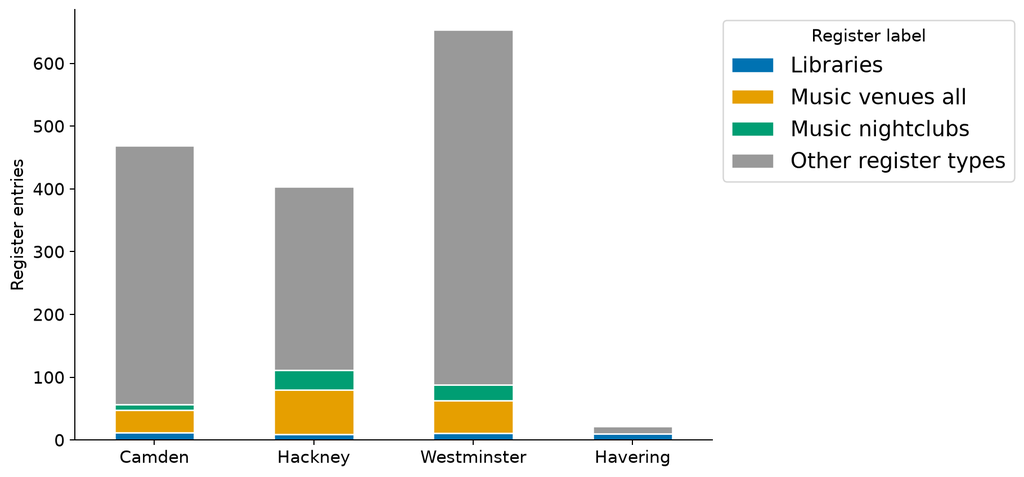

Westminster has the largest total. Middle music segments are harder to compare because their baselines differ.

## Grouped bars: a common baseline

```python
fig, ax = plt.subplots(figsize=(10, 4))
mix.plot.bar(ax=ax, color=palette, rot=0)
ax.set_ylabel("Register entries")
```

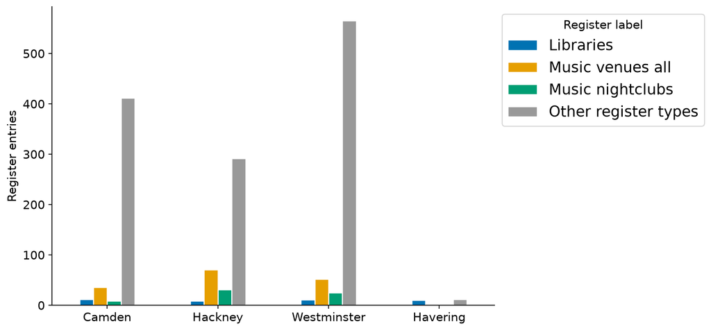

Hackney’s **71 Music venues all entries** exceed Camden’s **36**. Each separate bar starts from zero.

## Proportional bars: the borough’s entry mix

```python
props = mix.div(mix.sum(axis=1), axis=0) * 100
fig, ax = plt.subplots(figsize=(10, 4))
props.plot.bar(stacked=True, ax=ax, color=palette, rot=0)
ax.set_ylabel("Share of all borough entries (%)")
```

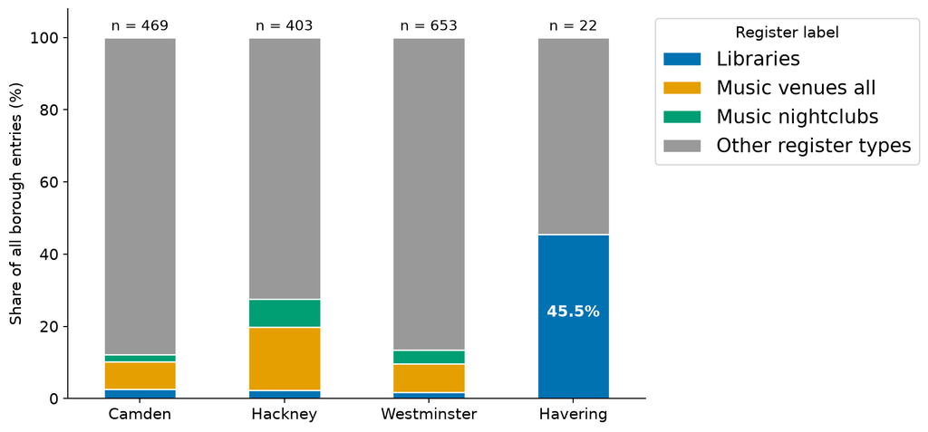

Havering: **10 / 22 = 45.5% Libraries**. Equal heights hide unequal totals, so keep **n** visible.

## Which margin? Which subset?

```python
row_shares = pd.crosstab(venues["borough_name"],
    venues["venue_type"], normalize="index")
```

| Calculation | Havering Libraries | Meaning |
| --- | --- | --- |
| Full borough row | 10 / 22 = **45.5%** | share of all Havering entries |
| Only three named types retained | 10 / 10 = **100%** | share among selected types |

Both calculations can be correct. They concern **different populations of entries**. Normalise the full row before narrowing the display, or retain Other.

## Stacked, grouped or proportional?

| Layout | Shows well | Limitation | London question |
| --- | --- | --- | --- |
| Stacked counts | totals and composition | middle segments lack common baseline | Which total is largest? |
| Grouped counts | individual values | wider; totals less obvious | Hackney versus Camden music entries? |
| Proportional stacked | mix despite unequal totals | hides size; middle segments still hard | What is Hackney’s entry mix? |

Keep category order and colours consistent. Display counts beside proportions when size matters.

## Colour and accessibility

[figure not shown]

- Use a tested palette, such as Okabe–Ito.
- Keep colours consistent between figures.
- Add labels, borders or line styles; colour alone is insufficient.
- Check contrast and readability at final size.

Our mean and median lines use different **line styles** as well as colours.

## Reuse the weekday and weekend category

Continue with the same **443,539 hires starting on 16–31 July 2025** as Week 5.

```python
trips = pd.read_csv(data_path(
    "tfl-bike-hire/bike_trips_16-31Jul2025_with_borough.csv"))
trips["day_type"] = "Weekday"
trips.loc[(trips["weekday"] == "Saturday") |
          (trips["weekday"] == "Sunday"), "day_type"] = "Weekend"
trips["day_type"] = trips["day_type"].astype("category")
day_counts = trips["day_type"].value_counts()
```

One row is one **recorded hire**. The same person may contribute several rows. `day_type` and `duration_min` have **zero missing values** in this extract.

## Bike-hire totals and the days represented

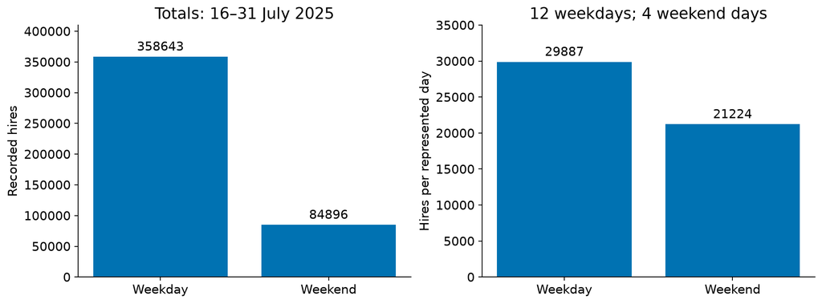

**358,643 weekday hires** and **84,896 weekend hires** cover **12 weekdays** and **four weekend days**.

Dividing by represented days gives **29,887 versus 21,224 hires per day**. The weekday difference remains, but is much smaller. This short July window does not establish a general annual pattern or trip purpose.

## Group counts become a bar plot

```python
hire_counts = trips.groupby("start_borough").size().sort_values(ascending=False)
fig, ax = plt.subplots(figsize=(11, 6))
ax.barh(hire_counts.index, hire_counts.values)
ax.invert_yaxis()
ax.set_xlabel("Recorded hires")
```

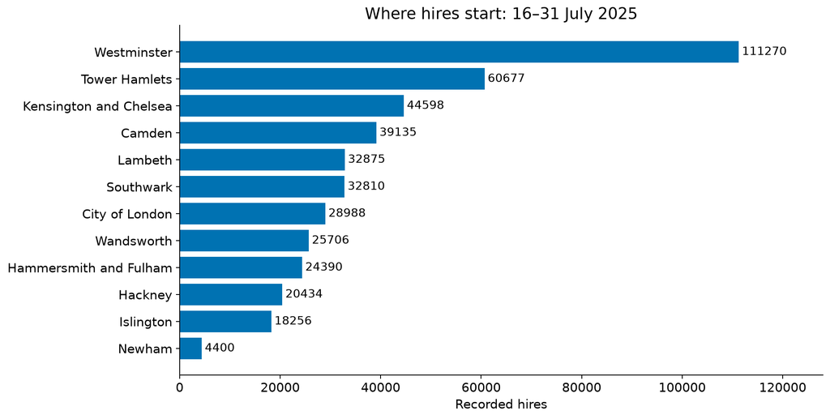

**Westminster: 111,270 starts.** These are hires from docking stations in the **12 represented borough areas**, not a ranking of all London cycling demand.

## Grouped summaries become grouped bars

```python
summary = trips.groupby("start_borough")["duration_min"].agg(
    ["count", "mean", "median"])
shown = summary.loc[["Westminster", "Tower Hamlets", "City of London", "Newham"]]
fig, ax = plt.subplots(figsize=(11, 5))
shown[["mean", "median"]].plot.bar(ax=ax, rot=0)
ax.set_ylabel("Recorded hire duration (minutes)")
```

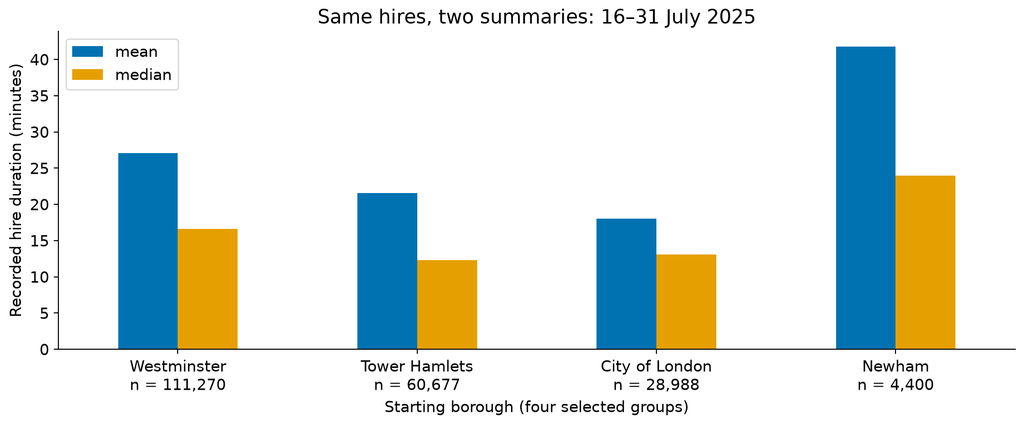

Newham: **mean 41.81, median 24.0 minutes**, from **4,400 hires**. A bar summarises many observations; it does not establish speed, distance or why people hired a bike.

## The same rates, two banding rules

Week 5 compared fixed thresholds with approximately equal-sized quantile groups. Draw that same table as grouped bars.

```python
borough_context["quantile_band"], edges = pd.qcut(
    rate, q=3, labels=["Low", "Medium", "High"], retbins=True)
band_counts = pd.DataFrame({
    "Fixed thresholds": borough_context["rate_band"].value_counts(sort=False),
    "Quantile bands": borough_context["quantile_band"].value_counts(sort=False)})
fig, ax = plt.subplots(figsize=(9, 4))
band_counts.plot.bar(ax=ax, rot=0)
ax.set_ylabel("Borough areas")
```

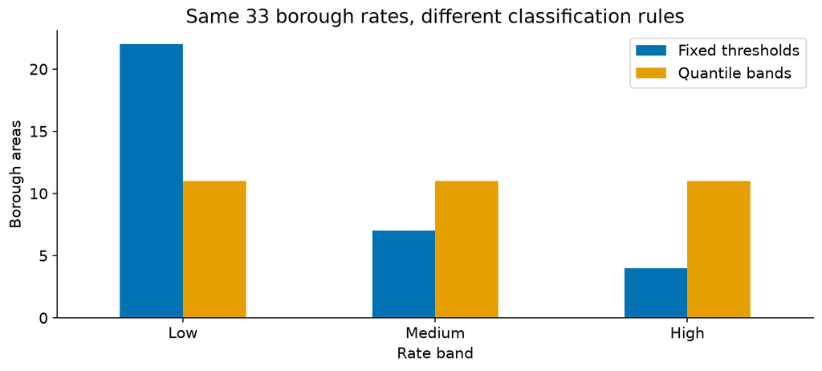

Fixed bands: **22 / 7 / 4**. Quantile bands: **11 / 11 / 11**. The rates did not change. Equal group sizes follow from the rule, not evidence of three natural levels of provision.

# Distributions and central tendency

1. **Describe centre and spread:** mean, median, quartiles and range.
2. **Inspect actual values:** historical mortality and recorded hire duration.
3. **Choose bins and a viewing window:** show what is included and omitted.
4. **Investigate unusual cases:** long hires and City of London, before changing data.

## Mean, median and mode

| Measure | Definition | London use |
| --- | --- | --- |
| Mean | sum / number of non-missing observations | equal-weight mean of 33 rates: **9.28** |
| Median | middle ordered value; average of two middle values when n is even | middle borough rate: **2.81** |
| Mode | most frequent value or category; ties possible | Archives: **544** entries |

Rate units: **entries per 10,000 residents**. A mean of borough rates is not the London-wide rate: borough populations differ.

## Distribution shape changes the summary

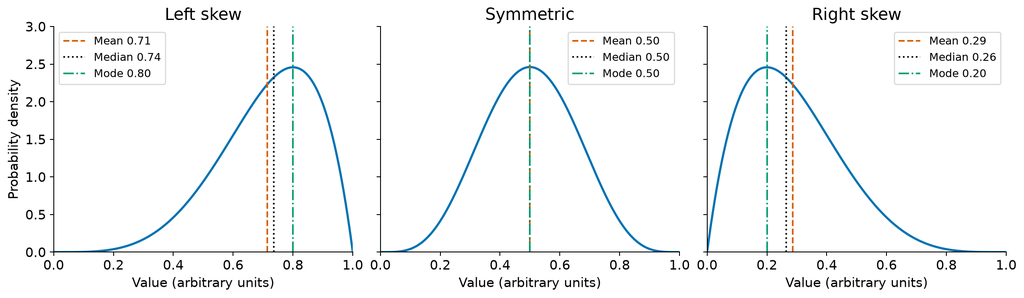

- A long **left tail** can pull the mean below the median.
- A long **right tail** can pull it above the median.
- In a symmetric unimodal distribution, the centres may coincide.

Income often has a right tail; an easy test may have a left tail. Retirement ages may cluster at institutional thresholds. **Inspect the actual data.**

## Life expectancy is not a typical age at death

[figure not shown]

For England, reconstructed life expectancy **at birth** varied around **35–40 years during 1600–1800**.

This does not mean most adults died at 35–40. Infant and child deaths lower the average. Surviving to adulthood changes the conditional expectation; adult mortality mattered too.

**Infant mortality:** deaths before age one per 1,000 live births. It differs from mortality before age five, ten or fifteen.

## Age at death: historical mortality data

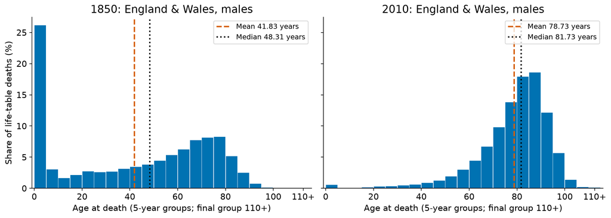

**1850:** 15.5% die before age one under that year’s rates; **2010:** 0.465%. Early deaths pull the mean below the median. Adult mortality changed too.

Each period table starts with **100,000 hypothetical births**, exposed throughout life to that year’s age-specific risks. Five-year age groups; final group **110+**. These are mortality-based estimates, not a traced birth cohort.

[Source: ONS, *Mortality in England and Wales*, Figures 1 and 3 (2012)](https://www.ons.gov.uk/peoplepopulationandcommunity/birthsdeathsandmarriages/deaths/articles/mortalityinenglandandwales/2012-12-17)

## The London rate distribution

```python
rates = borough_context["venues_per_10k_residents"]
rates.describe()
```

| Non-missing n | Mean | Std. dev. | Min | Q1 | Median | Q3 | Max |
| --- | --- | --- | --- | --- | --- | --- | --- |
| 33 | 9.28 | 23.73 | 0.88 | 1.51 | 2.81 | 7.86 | 137.04 |

Units: **register entries per 10,000 residents**. No rate values are missing.

The mean exceeds three times the median. The distribution helps explain why.

## Quartiles, IQR and range

| Summary | London result | Meaning |
| --- | --- | --- |
| Q1 | 1.51 | lower quartile of ordered rates |
| Q2 / median | 2.81 | middle rate |
| Q3 | 7.86 | upper quartile |
| IQR = Q3 − Q1 | **6.35** | spread of the middle half |
| Range = max − min | **136.16** | full observed spread |

```python
q1, q3 = rates.quantile([0.25, 0.75])
iqr = q3 - q1
```

All in **entries per 10,000 residents**. Quantile methods can interpolate; method matters with small n.

## Histogram or bar plot?

|  | Bar plot | Histogram |
| --- | --- | --- |
| Groups | named categories | numeric intervals, or bins |
| Position | often reorderable; preserve ordinal order | follows the numeric scale |
| Bars | separated | adjoining for contiguous bins |
| Height today | entry count for a type | area count in a rate interval |
| Question | Which type has more entries? | Where do rates cluster? |

A histogram **classifies numbers into bins**. Like `cut()`, it makes boundaries consequential. It does not preserve borough identities.

## Recorded hire durations: read the summary first

```python
# One observation is one recorded hire, with duration measured in minutes.
durations = trips["duration_min"]
print(durations.describe().round(2))
```

| Non-missing n | Mean | Median | Q1 | Q3 | Minimum | Maximum |
| --- | --- | --- | --- | --- | --- | --- |
| 443,539 | 22.97 | 14.0 | 8.1 | 23.0 | 0 | 75,882.8 |

**Units: minutes per recorded hire.** IQR = 23.0 − 8.1 = **14.9 minutes**. There are **199 zeros** and **269 durations above 1,440 minutes (24 hours)**, retained from Week 5.

The maximum is about **52.7 days**. A summary can alert us to something that needs investigation before we draw the distribution.

## All recorded durations: the full range

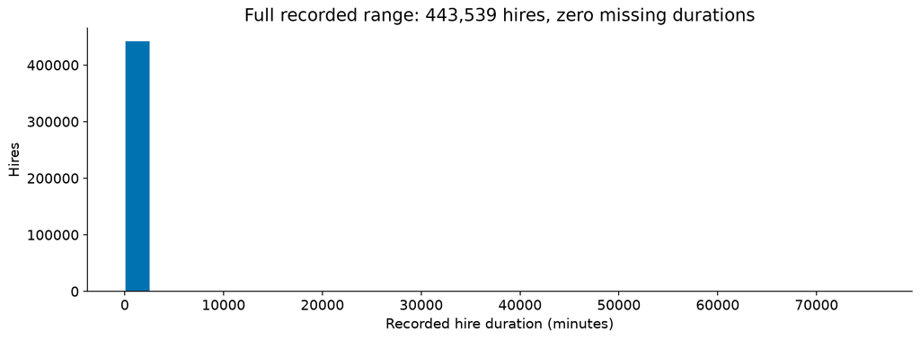

```python
fig, ax = plt.subplots(figsize=(11, 4))
ax.hist(durations, bins=30, color="#0072B2", edgecolor="white")
ax.set_xlabel("Recorded hire duration (minutes)")
ax.set_ylabel("Hires")
```

The long range compresses most hires into the first interval. The unusual values are visible as a **scale problem**, while the shorter-duration pattern is hard to read.